# Hospital Regression Analysis

In this notebook, I will go through my analysis with the goal of predicting the total cost to the hospital as a part of Dubai Future Foundation Case Study for a Business Intelligence Analyst.

## 1. Problem Definition

> How well can we predict the future cost to the hospital, given its characteristics and with previous examples of how much a similar treatment costed the hospital?

## 2. Data

The data comes directly from Dubai Future Foundation.

There is one main datasets:

- Hospital-Data.xlsx - which contains the hospital patients details such as `gender`, `age`, `weight`, `blood pressure`, `implant`, and the `cost to the hospital`, and more.
1. Data overview
2. Explanatory Data Analysis
3. Data-driven EDA and Feature Engineering
4. Data preparation for Regression Analysis
5. Regression Analysis
6. Machine Learning Algorithms
7. Conclusion

## 1. Data overview

In this section:

- Import libraries
- See the statistics of the dataset
- Check for missing values
- Drop the index

```python
#Importing libraries
import numpy as np
import pandas as pd
import matplotlib.pyplot as plt
import seaborn as sns
import statsmodels.api as sm
from sklearn.model_selection import train_test_split
from sklearn.linear_model import LinearRegression
from sklearn.ensemble import RandomForestRegressor
from sklearn.metrics import mean_absolute_error, r2_score, mean_squared_error
from sklearn.model_selection import RandomizedSearchCV
from sklearn.preprocessing import StandardScaler
from sklearn.model_selection import cross_val_score
sns.set(rc={'figure.figsize':(16,9),'axes.facecolor':'white'})
```

```python
#Importing dataset and seeing an overview of the data
hospital = pd.read_excel('Hospital - Data.xlsx')
hospital.head()
```

|  | SL. | AGE | GENDER | MARITAL STATUS | KEY COMPLAINTS -CODE | BODY WEIGHT | BODY HEIGHT | HR PULSE | BP -HIGH | BP-LOW | ... | CREATININE | MODE OF ARRIVAL | STATE AT THE TIME OF ARRIVAL | TYPE OF ADMSN | TOTAL LENGTH OF STAY | LENGTH OF STAY - ICU | LENGTH OF STAY- WARD | IMPLANT USED (Y/N) | COST OF IMPLANT | TOTAL COST TO HOSPITAL |
| --- | --- | --- | --- | --- | --- | --- | --- | --- | --- | --- | --- | --- | --- | --- | --- | --- | --- | --- | --- | --- | --- |
| 0 | 1 | 58.0 | M | MARRIED | other- heart | 49.2 | 160 | 118 | 100.0 | 80.0 | ... | 0.8 | AMBULANCE | ALERT | EMERGENCY | 25 | 12 | 13 | Y | 38000 | 660293.0 |
| 1 | 2 | 59.0 | M | MARRIED | CAD-DVD | 41.0 | 155 | 78 | 70.0 | 50.0 | ... | 1.7 | AMBULANCE | ALERT | EMERGENCY | 41 | 20 | 21 | Y | 39690 | 809130.0 |
| 2 | 3 | 82.0 | M | MARRIED | CAD-TVD | 46.6 | 164 | 100 | 110.0 | 80.0 | ... | 0.8 | WALKED IN | ALERT | ELECTIVE | 18 | 9 | 9 | N | 0 | 362231.0 |
| 3 | 4 | 46.0 | M | MARRIED | CAD-DVD | 80.0 | 173 | 122 | 110.0 | 80.0 | ... | 1.5 | AMBULANCE | ALERT | EMERGENCY | 14 | 13 | 1 | Y | 89450 | 629990.0 |
| 4 | 5 | 60.0 | M | MARRIED | CAD-DVD | 58.0 | 175 | 72 | 180.0 | 100.0 | ... | 1.9 | AMBULANCE | ALERT | EMERGENCY | 24 | 12 | 12 | N | 0 | 444876.0 |

5 rows × 24 columns

```python
#Dropping the index column
hospital = hospital.drop('SL.',axis=1)
```

```python
hospital.info()
```

```
<class 'pandas.core.frame.DataFrame'>
RangeIndex: 248 entries, 0 to 247
Data columns (total 23 columns):
 #   Column                        Non-Null Count  Dtype
---  ------                        --------------  -----
 0   AGE                           248 non-null    float64
 1   GENDER                        248 non-null    object
 2   MARITAL STATUS                248 non-null    object
 3   KEY COMPLAINTS -CODE          212 non-null    object
 4   BODY WEIGHT                   248 non-null    float64
 5   BODY HEIGHT                   248 non-null    int64
 6   HR PULSE                      248 non-null    int64
 7   BP -HIGH                      225 non-null    float64
 8   BP-LOW                        225 non-null    float64
 9   RR                            248 non-null    int64
 10  PAST MEDICAL HISTORY CODE     75 non-null     object
 11  HB                            246 non-null    float64
 12  UREA                          235 non-null    float64
 13  CREATININE                    215 non-null    float64
 14  MODE OF ARRIVAL               248 non-null    object
 15  STATE AT THE TIME OF ARRIVAL  248 non-null    object
 16  TYPE OF ADMSN                 248 non-null    object
 17  TOTAL LENGTH OF STAY          248 non-null    int64
 18  LENGTH OF STAY - ICU          248 non-null    int64
 19  LENGTH OF STAY- WARD          248 non-null    int64
 20  IMPLANT USED (Y/N)            248 non-null    object
 21  COST OF IMPLANT               248 non-null    int64
 22  TOTAL COST TO HOSPITAL        248 non-null    float64
dtypes: float64(8), int64(7), object(8)
memory usage: 44.7+ KB
```

```python
hospital.describe()
```

|  | AGE | BODY WEIGHT | BODY HEIGHT | HR PULSE | BP -HIGH | BP-LOW | RR | HB | UREA | CREATININE | TOTAL LENGTH OF STAY | LENGTH OF STAY - ICU | LENGTH OF STAY- WARD | COST OF IMPLANT | TOTAL COST TO HOSPITAL |
| --- | --- | --- | --- | --- | --- | --- | --- | --- | --- | --- | --- | --- | --- | --- | --- |
| count | 248.000000 | 248.000000 | 248.000000 | 248.000000 | 225.000000 | 225.000000 | 248.000000 | 246.000000 | 235.000000 | 215.000000 | 248.000000 | 248.000000 | 248.000000 | 248.000000 | 248.000000 |
| mean | 28.879837 | 37.524677 | 130.221774 | 92.229839 | 115.022222 | 71.875556 | 23.540323 | 12.894553 | 26.581702 | 0.746977 | 11.612903 | 3.475806 | 8.153226 | 8544.201613 | 198723.330282 |
| std | 25.899359 | 23.118822 | 39.170901 | 20.308740 | 22.536368 | 15.313176 | 3.840756 | 3.083237 | 15.998367 | 0.548641 | 5.392617 | 3.853520 | 3.755793 | 21521.877503 | 122587.492984 |
| min | 0.032877 | 2.020000 | 19.000000 | 41.000000 | 70.000000 | 39.000000 | 12.000000 | 5.000000 | 2.000000 | 0.100000 | 3.000000 | 0.000000 | 0.000000 | 0.000000 | 46093.000000 |
| 25% | 6.000000 | 15.000000 | 105.000000 | 78.000000 | 100.000000 | 60.000000 | 22.000000 | 11.300000 | 18.000000 | 0.300000 | 8.000000 | 1.000000 | 6.000000 | 0.000000 | 131652.750000 |
| 50% | 15.500000 | 40.900000 | 147.500000 | 90.000000 | 110.000000 | 70.000000 | 24.000000 | 12.350000 | 22.000000 | 0.700000 | 10.000000 | 2.000000 | 7.000000 | 0.000000 | 162660.500000 |
| 75% | 55.000000 | 58.250000 | 160.000000 | 104.000000 | 130.000000 | 80.000000 | 24.000000 | 14.000000 | 30.000000 | 1.000000 | 13.000000 | 4.000000 | 10.000000 | 0.000000 | 220614.000000 |
| max | 88.000000 | 85.000000 | 185.000000 | 155.000000 | 215.000000 | 140.000000 | 42.000000 | 25.700000 | 143.000000 | 5.200000 | 41.000000 | 30.000000 | 22.000000 | 196848.000000 | 887350.000000 |

## 2. Explanatory Data Analysis (EDA)

In this section:

- Perform explanatory data analysis
- Look for correlations in the data

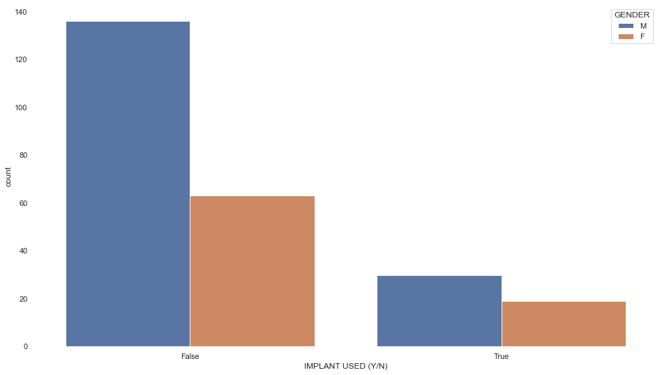

```python
sns.countplot(hue= hospital['GENDER'], x= hospital['IMPLANT USED (Y/N)'] == 'Y' )
```

```python
hospital.GENDER.value_counts()
```

```
M    166
F     82
Name: GENDER, dtype: int64
```

```python
hospital['IMPLANT USED (Y/N)'].value_counts()
```

```
N    199
Y     49
Name: IMPLANT USED (Y/N), dtype: int64
```

```python
# Check whether total length of stay is actually equal to the length of stay ICU + WARD
hospital['TOTAL LENGTH OF STAY'].sum(), hospital['LENGTH OF STAY - ICU'].sum() \
+ hospital['LENGTH OF STAY- WARD'].sum()
```

```
(2880, 2884)
```

```python
#There seems to a discrepency of 4 days between the summation of ICU + WARD and TOTAL Length of stay
#We will create a new column and investigate
hospital['total_length_of_stay'] = hospital['LENGTH OF STAY - ICU'] + hospital['LENGTH OF STAY- WARD']
```

```python
#To see all the rows with discrepencies
hospital[hospital['total_length_of_stay']!= hospital['TOTAL LENGTH OF STAY']][['total_length_of_stay',
                                                                               'TOTAL LENGTH OF STAY',
                                                                               'LENGTH OF STAY- WARD',
                                                                              'LENGTH OF STAY - ICU']]
```

|  | total_length_of_stay | TOTAL LENGTH OF STAY | LENGTH OF STAY- WARD | LENGTH OF STAY - ICU |
| --- | --- | --- | --- | --- |
| 15 | 7 | 9 | 3 | 4 |
| 27 | 16 | 15 | 10 | 6 |
| 141 | 8 | 7 | 6 | 2 |
| 161 | 26 | 25 | 20 | 6 |
| 163 | 13 | 12 | 10 | 3 |
| 164 | 13 | 12 | 12 | 1 |
| 167 | 11 | 10 | 9 | 2 |

```python
# Dropping total length of stay
hospital.drop('TOTAL LENGTH OF STAY',axis=1, inplace=True)
```

```
[Text(0.5, 1.0, 'Correlation heatmap')]
```

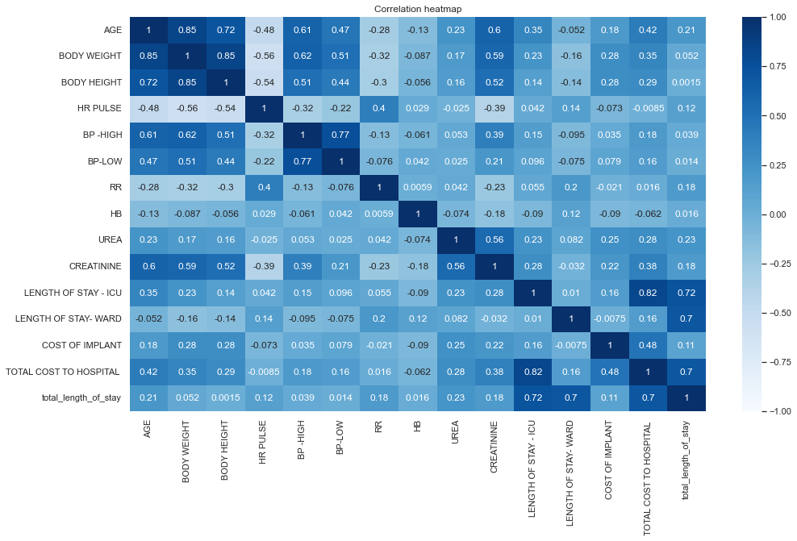

```python
#Lets create a heatmap to see whether there are any correlations
sns.heatmap(hospital.corr(), vmin=-1, vmax=1, annot=True, cmap='Blues').set(title= 'Correlation heatmap')
```

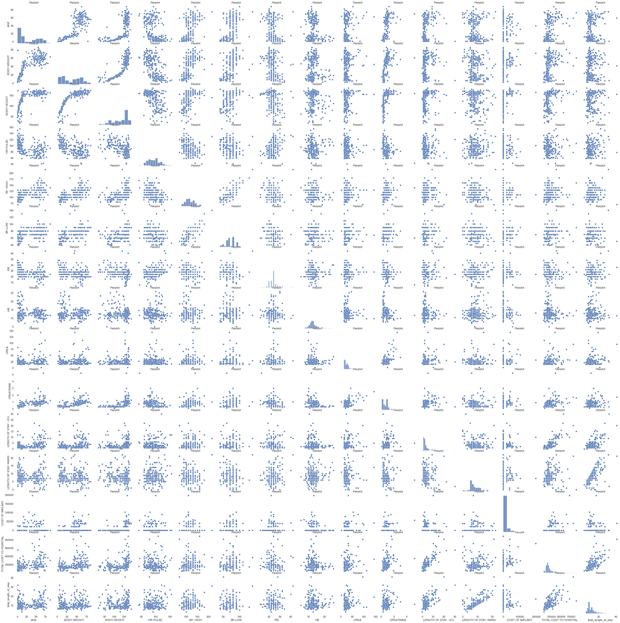

```python
# Lets create a pairplot to see if we can find anything interesting
sns.pairplot(hospital).set(title= 'Pairplot')
```

### Key Takeaways

**Length of stay:**

- The sum of 'Length of stay' of ward + ICU != TOTAL LENGTH OF STAY
- Created a new column
- Dropped the old column

**Correlation Matrix:**

- Length of stay - ICU has a very high correlation on the Total Cost, 82%
- Followed by cost of implant and age, 48% and 42%, respectively

-**Other takeaways:**

- 67% of the samples are men
- 19% of the samples already have implants
- As age increases, bodyweight increases, bodyheight increases, HR pulse decreases

**Pairplot:**

- Theres a positive linear relationship between Cost and Stay

## 3. Data-Driven EDA and Feature engineering

The data-driven exploratory data analysis will include:

- Dealing with the distribution of the data, check the `Skewness` and `Kurtosis`
- Dealing with missing data
- Develop a strategy for the analysis

> **Skewness** refers to a distortion or asymmetry that deviates from the symmetrical bell curve, or normal distribution, in a set of data.

> **Kurtosis** the sharpness of the peak of a frequency-distribution curve.
> - acceptable ranges for Skewness and Kurtosis to assume a `Normal Distribution` = *-1.5 to 1.5*

```
[Text(0.5, 1.0, 'Distribution of Total cost to Hospital')]
```

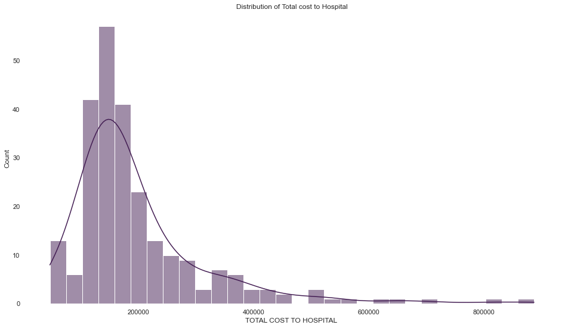

```python
#Create a histplot for the dependent variable to see the distribution
sns.histplot(hospital['TOTAL COST TO HOSPITAL '],kde=True, color="#421C52").set(title='Distribution of Total cost to Hospital')
```

```python
#To check the Skewness and Kurtosis of the Target Variable
print("Skewness: %f" % hospital['TOTAL COST TO HOSPITAL '].skew())
print("Kurtosis: %f" % hospital['TOTAL COST TO HOSPITAL '].kurt())
```

```
Skewness: 2.455584
Kurtosis: 8.087163
```

### Key Takeaways

- Deviates from the normal distribution
- Have appreciable positive skewness of 2.45
- Shows peakedness and kurtosis of 8.09

The Skewness and Kurtosis are both above the range of -1.5 to 1.5

**Strategy:**

- log transformation

**Log transformation** The Log Transformation is used to transform skewed datasets to achieve linearity (near-normal distribution)

```
[Text(0.5, 1.0, 'Log Transformation Total cost to Hospital')]
```

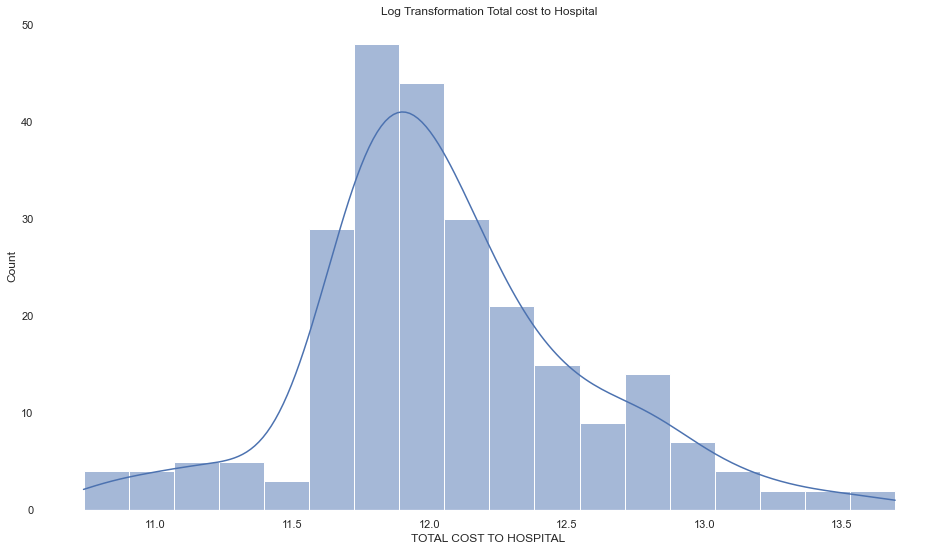

```python
# Create a histogram for log transformed Y
sns.histplot(np.log(hospital['TOTAL COST TO HOSPITAL ']),kde=True).set(title='Log Transformation Total cost to Hospital')
```

```python
# To check the skewness and kurtosis of the log transformed target variable
print("Skewness: %f" % np.log(hospital['TOTAL COST TO HOSPITAL ']).skew())
print("Kurtosis: %f" % np.log(hospital['TOTAL COST TO HOSPITAL ']).kurt())
```

```
Skewness: 0.395575
Kurtosis: 0.921752
```

### Key Takeaways

- The log transformation was effective and now assumes a normal distribution
- Skewness and Kurtosis both in ranges of -1.5 to 1.5

Now to see the distribution of the features

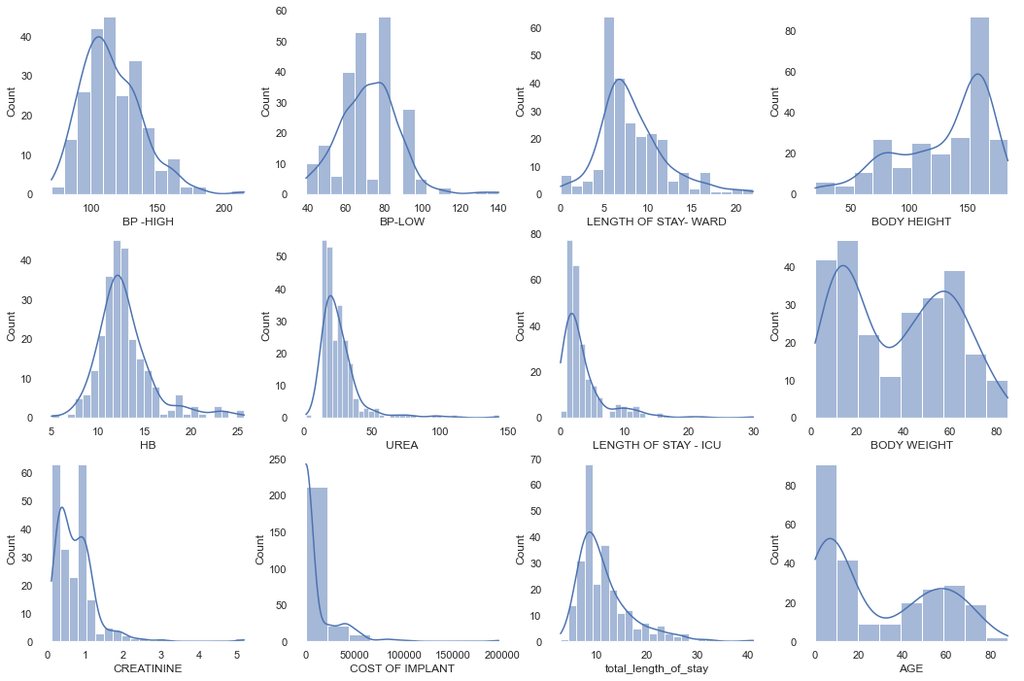

```python
# Creates histogram subplots to see the skewness of the features
fig, axs = plt.subplots(3, 4, figsize=(18, 12))
sns.histplot(hospital['BP -HIGH'], kde= True, ax=axs[0, 0],)
sns.histplot(hospital['BP-LOW'], kde= True, ax=axs[0, 1])
sns.histplot(hospital['HB'], kde= True, ax=axs[1, 0])
sns.histplot(hospital['UREA'], kde= True, ax=axs[1, 1])
sns.histplot(hospital['CREATININE'], kde= True, ax=axs[2, 0])
sns.histplot(hospital['COST OF IMPLANT'], kde= True, ax=axs[2, 1])
sns.histplot(hospital['LENGTH OF STAY- WARD'], kde= True, ax=axs[0, 2])
sns.histplot(hospital['LENGTH OF STAY - ICU'], kde= True, ax=axs[1, 2])
sns.histplot(hospital['total_length_of_stay'], kde= True, ax=axs[2, 2])
sns.histplot(hospital['BODY HEIGHT'],kde=True, ax=axs[0, 3])
sns.histplot(hospital['BODY WEIGHT'],kde=True, ax=axs[1, 3])
sns.histplot(hospital['AGE'],kde=True, ax=axs[2, 3])
plt.show()
```

### Key Takeaways

From the distribution of features we can observe:

- BP high and Low seem to be at normal ranges with the exception of a few cases, avg 120/80
- Body height seems to be normal, international avg according to WHO is 160 cm for women and 170 cm for men
- Hemoglobin count seems to be normal, ~14 – 18 g/dL for men and 12 – 15 g/dL for women
- Age, as there seem to be a lot of kids, hence the skewness
- Creatinine and Urea, 0.6 – 1.3 mg/dL and 6 – 24 mg/dL

**Strategy:**

- Deal with missing values first,

{Optional}

- Check the skewness and kurtosis,
- Log transform anything that violates the skewness and kurtosis range

**Note:** Log transformation does not work for 0 or negative integers

```python
# Finding the missing numerical and categorical values
missing_numerical = [var for var in hospital.columns if hospital[var].isnull().mean()> 0
                     and hospital[var].dtypes != 'O']
missing_categorical = [var for var in hospital.columns if hospital[var].isnull().mean()> 0
                     and hospital[var].dtypes == 'O']
print(f'missing_numerical: {missing_numerical},\nmissing_categorical: {missing_categorical}')
```

```
missing_numerical: ['BP -HIGH', 'BP-LOW', 'HB', 'UREA', 'CREATININE'],
missing_categorical: ['KEY COMPLAINTS -CODE', 'PAST MEDICAL HISTORY CODE']
```

```python
# fill numeric rows with Median
for label, content in hospital.items():
    if pd.api.types.is_numeric_dtype(content):
        if pd.isnull(content).sum():
            #Filling missing numeric with Median
            hospital[label] = content.fillna(content.median())
```

**Note:** As our data contains outliers, Median is not affected by outliers

e.g. 5 people with the following salaries - 10, 10, 10, 10, 1000

- mean - 208
- median - 10

```python
# fill categorical rows
# As there are only few NA's in the KEY COMPLAINTS -CODE column, we can fill the missing rows with OTHER
hospital['KEY COMPLAINTS -CODE'].fillna('OTHER', inplace=True)

#Since PAST MEDICAL HISTORY CODE column has more than 50% NA's, I will drop the column
hospital = hospital.drop('PAST MEDICAL HISTORY CODE',axis=1)
```

```python
# Finding the missing numerical and categorical values
missing_numerical = [var for var in hospital.columns if hospital[var].isnull().mean()> 0
                     and hospital[var].dtypes != 'O']
missing_categorical = [var for var in hospital.columns if hospital[var].isnull().mean()> 0
                     and hospital[var].dtypes == 'O']
print(f'missing_numerical: {missing_numerical},\nmissing_categorical: {missing_categorical}')
```

```
missing_numerical: [],
missing_categorical: []
```

```python
# Creating a dataframe of ints and floats
df1 = hospital.select_dtypes([int, float])
# for i, col in enumerate(df1.columns):
#     plt.figure(i)
#     sns.histplot(x=col, data=df1, kde=True)
```

```python
for label, col in enumerate(df1):
    print(label,"Skewness: %f" % df1[col].skew())
    print(label,"Kurtosis: %f" % df1[col].kurt())
```

```
0 Skewness: 0.466891
0 Kurtosis: -1.372924
1 Skewness: 0.127305
1 Kurtosis: -1.392069
2 Skewness: -0.885674
2 Kurtosis: -0.251092
3 Skewness: 0.330071
3 Kurtosis: -0.199543
4 Skewness: 0.937604
4 Kurtosis: 1.782032
5 Skewness: 0.531453
5 Kurtosis: 2.269801
6 Skewness: 0.760499
6 Kurtosis: 3.747282
7 Skewness: 1.504747
7 Kurtosis: 3.637184
8 Skewness: 3.744536
8 Kurtosis: 19.172017
9 Skewness: 3.613607
9 Kurtosis: 24.667259
10 Skewness: 2.997234
10 Kurtosis: 12.381168
11 Skewness: 0.960647
11 Kurtosis: 1.615304
12 Skewness: 4.119912
12 Kurtosis: 25.728311
13 Skewness: 2.455584
13 Kurtosis: 8.087163
14 Skewness: 1.844533
14 Kurtosis: 4.599267
```

```python
mydict = {}
for k,v in enumerate(df1.columns):
    mydict[k] = v
print(mydict)
```

```
{0: 'AGE', 1: 'BODY WEIGHT', 2: 'BODY HEIGHT', 3: 'HR PULSE', 4: 'BP -HIGH', 5: 'BP-LOW', 6: 'RR', 7: 'HB', 8: 'UREA', 9: 'CREATININE', 10: 'LENGTH OF STAY - ICU', 11: 'LENGTH OF STAY- WARD', 12: 'COST OF IMPLANT', 13: 'TOTAL COST TO HOSPITAL ', 14: 'total_length_of_stay'}
```

```python
#Transform UREA, CREATININE, LENGTH OF STAY - ICU, LENGTH OF STAY - WARD, total_length_of_stay
hospital_transformed = hospital.drop(['CREATININE', 'UREA'],axis=1)
df2 = np.log(df1[['UREA', 'CREATININE']])
hospital_transformed = pd.concat([hospital_transformed, df2],axis=1)
#The length of stay icu, ward, and total stay all had zero values, hence could not be transformed
```

## 4. Data preparation for Regression Analysis

Tasks for this section,

- Create subsets of the data for the analysis (X and Y)
- Dummy variables/ One hot encoding

**Subsets:**

- Subset 1: Dropped target variable and extra dummy variables to avoid multicollinearity
- Subset 2: Log-transformed variables
- Subset 3: Scaled variables (although scaling does not matter in linear regression)

**Multicollinearity:** Multicollinearity occurs when two or more independent variables are highly correlated with one another in a regression model.

```python
# Using dummy variables to transform the categorical columns
hospital_dummy = pd.get_dummies(hospital)
hospital_dummy_transformed = pd.get_dummies(hospital_transformed)
```

```python
#Subset 1: Dropped target variable and extra dummy variables to avoid multicollinearity
X = hospital_dummy.drop(['GENDER_F','MARITAL STATUS_MARRIED','KEY COMPLAINTS -CODE_OTHER',
                    'TOTAL COST TO HOSPITAL ','MODE OF ARRIVAL_WALKED IN',
                   'TYPE OF ADMSN_EMERGENCY', 'IMPLANT USED (Y/N)_N','total_length_of_stay'], axis=1)
y = hospital_dummy['TOTAL COST TO HOSPITAL ']
```

```python
#Subset 2: log-transformed variables
X_transformed = hospital_dummy_transformed.drop(['GENDER_F','MARITAL STATUS_MARRIED',
                                                 'KEY COMPLAINTS -CODE_OTHER',
                    'TOTAL COST TO HOSPITAL ','MODE OF ARRIVAL_WALKED IN',
                   'TYPE OF ADMSN_EMERGENCY', 'IMPLANT USED (Y/N)_N','total_length_of_stay'], axis=1)
y_transformed = np.log(hospital_dummy_transformed['TOTAL COST TO HOSPITAL '])
```

```python
#Subset 3: scaled
X_scaled = StandardScaler().fit_transform(X)
```

## 5. Regression Analysis

In this section:

- Perform regression analysis using Linear Regression
- Creating a B0 constant

**Models:**

1. Model 1: Nothing log-transformed
2. Model 2: Log-transformed features and dependent variable
3. Model 3: Only log transformed dependent variable with untransformed features
4. Model 4: Same as model 1 but with scaled variables

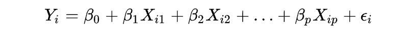

Where Y is the dependent variable, B0 is the constant, X(n) is the feature, B(n) is the slope of the feature.

```python
# adding a constant B0 to the X
X_cons = sm.add_constant(X)
X_transformed_cons = sm.add_constant(X_transformed)
X_scaled_cons = sm.add_constant(X_scaled)
```

```python
#Model 1
model_1 = sm.OLS(y, X_cons).fit()
model_1.summary()
```

OLS Regression Results

| Dep. Variable: | TOTAL COST TO HOSPITAL | R-squared: | 0.871 |
| --- | --- | --- | --- |
| Model: | OLS | Adj. R-squared: | 0.851 |
| Method: | Least Squares | F-statistic: | 43.90 |
| Date: | Wed, 22 Jun 2022 | Prob (F-statistic): | 1.10e-77 |
| Time: | 01:14:03 | Log-Likelihood: | -3002.9 |
| No. Observations: | 248 | AIC: | 6074. |
| Df Residuals: | 214 | BIC: | 6193. |
| Df Model: | 33 |  |  |
| Covariance Type: | nonrobust |  |  |

|  | coef | std err | t | P>\|t\| | [0.025 | 0.975] |
| --- | --- | --- | --- | --- | --- | --- |
| const | -1.257e+05 | 4.44e+04 | -2.831 | 0.005 | -2.13e+05 | -3.82e+04 |
| AGE | 291.2891 | 337.717 | 0.863 | 0.389 | -374.389 | 956.967 |
| BODY WEIGHT | -578.4075 | 409.043 | -1.414 | 0.159 | -1384.676 | 227.861 |
| BODY HEIGHT | 377.1939 | 165.719 | 2.276 | 0.024 | 50.544 | 703.844 |
| HR PULSE | 360.9545 | 203.460 | 1.774 | 0.077 | -40.089 | 761.998 |
| BP -HIGH | 53.7237 | 260.592 | 0.206 | 0.837 | -459.932 | 567.380 |
| BP-LOW | 75.2708 | 344.591 | 0.218 | 0.827 | -603.957 | 754.499 |
| RR | -283.7234 | 954.041 | -0.297 | 0.766 | -2164.244 | 1596.797 |
| HB | 466.7689 | 1146.144 | 0.407 | 0.684 | -1792.409 | 2725.947 |
| UREA | -574.6697 | 290.170 | -1.980 | 0.049 | -1146.628 | -2.712 |
| CREATININE | 4.516e+04 | 1.32e+04 | 3.431 | 0.001 | 1.92e+04 | 7.11e+04 |
| LENGTH OF STAY - ICU | 2.21e+04 | 989.123 | 22.342 | 0.000 | 2.01e+04 | 2.4e+04 |
| LENGTH OF STAY- WARD | 5269.2340 | 896.635 | 5.877 | 0.000 | 3501.867 | 7036.602 |
| COST OF IMPLANT | 2.0283 | 0.254 | 7.992 | 0.000 | 1.528 | 2.529 |
| GENDER_M | -3587.9102 | 7130.129 | -0.503 | 0.615 | -1.76e+04 | 1.05e+04 |
| MARITAL STATUS_UNMARRIED | 4419.5481 | 1.56e+04 | 0.284 | 0.777 | -2.63e+04 | 3.51e+04 |
| KEY COMPLAINTS -CODE_ACHD | 8698.5865 | 1.51e+04 | 0.576 | 0.565 | -2.11e+04 | 3.85e+04 |
| KEY COMPLAINTS -CODE_CAD-DVD | 2.919e+04 | 1.4e+04 | 2.090 | 0.038 | 1656.481 | 5.67e+04 |
| KEY COMPLAINTS -CODE_CAD-SVD | 3.627e+04 | 3.64e+04 | 0.998 | 0.320 | -3.54e+04 | 1.08e+05 |
| KEY COMPLAINTS -CODE_CAD-TVD | 4.649e+04 | 1.42e+04 | 3.270 | 0.001 | 1.85e+04 | 7.45e+04 |
| KEY COMPLAINTS -CODE_CAD-VSD | 4.098e+04 | 4.93e+04 | 0.832 | 0.406 | -5.61e+04 | 1.38e+05 |
| KEY COMPLAINTS -CODE_OS-ASD | 2.115e+04 | 1.57e+04 | 1.349 | 0.179 | -9752.185 | 5.21e+04 |
| KEY COMPLAINTS -CODE_PM-VSD | 4.734e+04 | 2.36e+04 | 2.009 | 0.046 | 903.043 | 9.38e+04 |
| KEY COMPLAINTS -CODE_RHD | -8416.5214 | 1.71e+04 | -0.492 | 0.623 | -4.22e+04 | 2.53e+04 |
| KEY COMPLAINTS -CODE_other- heart | 6782.9036 | 1.22e+04 | 0.555 | 0.580 | -1.73e+04 | 3.09e+04 |
| KEY COMPLAINTS -CODE_other- respiratory | 9210.6860 | 1.61e+04 | 0.574 | 0.567 | -2.24e+04 | 4.08e+04 |
| KEY COMPLAINTS -CODE_other-general | -6.953e+04 | 5.34e+04 | -1.302 | 0.194 | -1.75e+05 | 3.57e+04 |
| KEY COMPLAINTS -CODE_other-nervous | 8261.8948 | 3.03e+04 | 0.272 | 0.786 | -5.16e+04 | 6.81e+04 |
| KEY COMPLAINTS -CODE_other-tertalogy | 3.935e+04 | 1.64e+04 | 2.401 | 0.017 | 7052.029 | 7.16e+04 |
| MODE OF ARRIVAL_AMBULANCE | 4.826e+04 | 3.68e+04 | 1.311 | 0.191 | -2.43e+04 | 1.21e+05 |
| MODE OF ARRIVAL_TRANSFERRED | -2.76e+04 | 2.53e+04 | -1.091 | 0.277 | -7.75e+04 | 2.23e+04 |
| STATE AT THE TIME OF ARRIVAL_ALERT | 1.899e+04 | 3.07e+04 | 0.618 | 0.537 | -4.16e+04 | 7.96e+04 |
| STATE AT THE TIME OF ARRIVAL_CONFUSED | -1.447e+05 | 5.45e+04 | -2.656 | 0.008 | -2.52e+05 | -3.73e+04 |
| TYPE OF ADMSN_ELECTIVE | 5.413e+04 | 3.58e+04 | 1.510 | 0.132 | -1.65e+04 | 1.25e+05 |
| IMPLANT USED (Y/N)_Y | 1.5e+04 | 1.48e+04 | 1.014 | 0.312 | -1.42e+04 | 4.42e+04 |

| Omnibus: | 226.677 | Durbin-Watson: | 1.903 |
| --- | --- | --- | --- |
| Prob(Omnibus): | 0.000 | Jarque-Bera (JB): | 9380.922 |
| Skew: | 3.315 | Prob(JB): | 0.00 |
| Kurtosis: | 32.392 | Cond. No. | 3.70e+15 |

Notes:  
[1] Standard Errors assume that the covariance matrix of the errors is correctly specified.  
[2] The smallest eigenvalue is 9.67e-21. This might indicate that there are  
strong multicollinearity problems or that the design matrix is singular.

```python
#Model 2: log transformed X and Y
model_2 = sm.OLS(y_transformed, X_transformed_cons).fit()
model_2.summary()
```

OLS Regression Results

| Dep. Variable: | TOTAL COST TO HOSPITAL | R-squared: | 0.841 |
| --- | --- | --- | --- |
| Model: | OLS | Adj. R-squared: | 0.817 |
| Method: | Least Squares | F-statistic: | 34.36 |
| Date: | Wed, 22 Jun 2022 | Prob (F-statistic): | 3.68e-68 |
| Time: | 01:14:03 | Log-Likelihood: | 46.043 |
| No. Observations: | 248 | AIC: | -24.09 |
| Df Residuals: | 214 | BIC: | 95.37 |
| Df Model: | 33 |  |  |
| Covariance Type: | nonrobust |  |  |

|  | coef | std err | t | P>\|t\| | [0.025 | 0.975] |
| --- | --- | --- | --- | --- | --- | --- |
| const | 7.2742 | 0.189 | 38.417 | 0.000 | 6.901 | 7.647 |
| AGE | 0.0012 | 0.002 | 0.805 | 0.422 | -0.002 | 0.004 |
| BODY WEIGHT | -0.0002 | 0.002 | -0.130 | 0.897 | -0.004 | 0.003 |
| BODY HEIGHT | 0.0012 | 0.001 | 1.558 | 0.121 | -0.000 | 0.003 |
| HR PULSE | 0.0017 | 0.001 | 1.781 | 0.076 | -0.000 | 0.003 |
| BP -HIGH | 0.0014 | 0.001 | 1.152 | 0.251 | -0.001 | 0.004 |
| BP-LOW | -0.0005 | 0.002 | -0.299 | 0.765 | -0.004 | 0.003 |
| RR | -0.0064 | 0.004 | -1.463 | 0.145 | -0.015 | 0.002 |
| HB | 0.0002 | 0.005 | 0.033 | 0.974 | -0.010 | 0.010 |
| LENGTH OF STAY - ICU | 0.0792 | 0.005 | 17.528 | 0.000 | 0.070 | 0.088 |
| LENGTH OF STAY- WARD | 0.0338 | 0.004 | 8.272 | 0.000 | 0.026 | 0.042 |
| COST OF IMPLANT | 4.809e-06 | 1.16e-06 | 4.146 | 0.000 | 2.52e-06 | 7.1e-06 |
| UREA | -0.0687 | 0.040 | -1.726 | 0.086 | -0.147 | 0.010 |
| CREATININE | 0.1744 | 0.044 | 3.959 | 0.000 | 0.088 | 0.261 |
| GENDER_M | 0.0248 | 0.032 | 0.768 | 0.443 | -0.039 | 0.089 |
| MARITAL STATUS_UNMARRIED | 0.0615 | 0.071 | 0.865 | 0.388 | -0.079 | 0.202 |
| KEY COMPLAINTS -CODE_ACHD | -0.0043 | 0.070 | -0.061 | 0.951 | -0.142 | 0.133 |
| KEY COMPLAINTS -CODE_CAD-DVD | 0.1284 | 0.065 | 1.990 | 0.048 | 0.001 | 0.256 |
| KEY COMPLAINTS -CODE_CAD-SVD | 0.0570 | 0.167 | 0.340 | 0.734 | -0.273 | 0.387 |
| KEY COMPLAINTS -CODE_CAD-TVD | 0.2376 | 0.066 | 3.620 | 0.000 | 0.108 | 0.367 |
| KEY COMPLAINTS -CODE_CAD-VSD | 0.2346 | 0.227 | 1.035 | 0.302 | -0.212 | 0.682 |
| KEY COMPLAINTS -CODE_OS-ASD | 0.1529 | 0.073 | 2.085 | 0.038 | 0.008 | 0.298 |
| KEY COMPLAINTS -CODE_PM-VSD | 0.3336 | 0.109 | 3.057 | 0.003 | 0.118 | 0.549 |
| KEY COMPLAINTS -CODE_RHD | 0.0736 | 0.079 | 0.930 | 0.354 | -0.082 | 0.230 |
| KEY COMPLAINTS -CODE_other- heart | 0.0831 | 0.058 | 1.437 | 0.152 | -0.031 | 0.197 |
| KEY COMPLAINTS -CODE_other- respiratory | 0.0544 | 0.074 | 0.740 | 0.460 | -0.090 | 0.199 |
| KEY COMPLAINTS -CODE_other-general | -0.8838 | 0.234 | -3.770 | 0.000 | -1.346 | -0.422 |
| KEY COMPLAINTS -CODE_other-nervous | 0.1233 | 0.139 | 0.884 | 0.378 | -0.152 | 0.398 |
| KEY COMPLAINTS -CODE_other-tertalogy | 0.3085 | 0.076 | 4.057 | 0.000 | 0.159 | 0.458 |
| MODE OF ARRIVAL_AMBULANCE | 0.2388 | 0.168 | 1.421 | 0.157 | -0.092 | 0.570 |
| MODE OF ARRIVAL_TRANSFERRED | -0.2010 | 0.114 | -1.766 | 0.079 | -0.425 | 0.023 |
| STATE AT THE TIME OF ARRIVAL_ALERT | 3.7036 | 0.135 | 27.401 | 0.000 | 3.437 | 3.970 |
| STATE AT THE TIME OF ARRIVAL_CONFUSED | 3.5707 | 0.177 | 20.189 | 0.000 | 3.222 | 3.919 |
| TYPE OF ADMSN_ELECTIVE | 0.2969 | 0.164 | 1.807 | 0.072 | -0.027 | 0.621 |
| IMPLANT USED (Y/N)_Y | 0.2119 | 0.068 | 3.116 | 0.002 | 0.078 | 0.346 |

| Omnibus: | 17.826 | Durbin-Watson: | 1.878 |
| --- | --- | --- | --- |
| Prob(Omnibus): | 0.000 | Jarque-Bera (JB): | 23.292 |
| Skew: | -0.522 | Prob(JB): | 8.75e-06 |
| Kurtosis: | 4.079 | Cond. No. | 4.43e+15 |

Notes:  
[1] Standard Errors assume that the covariance matrix of the errors is correctly specified.  
[2] The smallest eigenvalue is 6.75e-21. This might indicate that there are  
strong multicollinearity problems or that the design matrix is singular.

```python
# Model 3: only log transformed y
model_3 = sm.OLS(y_transformed, X_cons).fit()
model_3.summary()
```

OLS Regression Results

| Dep. Variable: | TOTAL COST TO HOSPITAL | R-squared: | 0.839 |
| --- | --- | --- | --- |
| Model: | OLS | Adj. R-squared: | 0.814 |
| Method: | Least Squares | F-statistic: | 33.75 |
| Date: | Wed, 22 Jun 2022 | Prob (F-statistic): | 1.74e-67 |
| Time: | 01:14:03 | Log-Likelihood: | 44.191 |
| No. Observations: | 248 | AIC: | -20.38 |
| Df Residuals: | 214 | BIC: | 99.07 |
| Df Model: | 33 |  |  |
| Covariance Type: | nonrobust |  |  |

|  | coef | std err | t | P>\|t\| | [0.025 | 0.975] |
| --- | --- | --- | --- | --- | --- | --- |
| const | 6.7925 | 0.205 | 33.153 | 0.000 | 6.389 | 7.196 |
| AGE | 0.0016 | 0.002 | 1.042 | 0.298 | -0.001 | 0.005 |
| BODY WEIGHT | -7.279e-05 | 0.002 | -0.039 | 0.969 | -0.004 | 0.004 |
| BODY HEIGHT | 0.0013 | 0.001 | 1.687 | 0.093 | -0.000 | 0.003 |
| HR PULSE | 0.0017 | 0.001 | 1.823 | 0.070 | -0.000 | 0.004 |
| BP -HIGH | 0.0013 | 0.001 | 1.065 | 0.288 | -0.001 | 0.004 |
| BP-LOW | -0.0003 | 0.002 | -0.175 | 0.861 | -0.003 | 0.003 |
| RR | -0.0064 | 0.004 | -1.443 | 0.150 | -0.015 | 0.002 |
| HB | 0.0009 | 0.005 | 0.163 | 0.871 | -0.010 | 0.011 |
| UREA | -0.0024 | 0.001 | -1.816 | 0.071 | -0.005 | 0.000 |
| CREATININE | 0.2134 | 0.061 | 3.514 | 0.001 | 0.094 | 0.333 |
| LENGTH OF STAY - ICU | 0.0788 | 0.005 | 17.278 | 0.000 | 0.070 | 0.088 |
| LENGTH OF STAY- WARD | 0.0337 | 0.004 | 8.150 | 0.000 | 0.026 | 0.042 |
| COST OF IMPLANT | 4.834e-06 | 1.17e-06 | 4.129 | 0.000 | 2.53e-06 | 7.14e-06 |
| GENDER_M | 0.0189 | 0.033 | 0.575 | 0.566 | -0.046 | 0.084 |
| MARITAL STATUS_UNMARRIED | 0.0631 | 0.072 | 0.879 | 0.381 | -0.078 | 0.205 |
| KEY COMPLAINTS -CODE_ACHD | -0.0213 | 0.070 | -0.306 | 0.760 | -0.159 | 0.116 |
| KEY COMPLAINTS -CODE_CAD-DVD | 0.1060 | 0.064 | 1.646 | 0.101 | -0.021 | 0.233 |
| KEY COMPLAINTS -CODE_CAD-SVD | 0.0375 | 0.168 | 0.224 | 0.823 | -0.293 | 0.368 |
| KEY COMPLAINTS -CODE_CAD-TVD | 0.2146 | 0.066 | 3.271 | 0.001 | 0.085 | 0.344 |
| KEY COMPLAINTS -CODE_CAD-VSD | 0.1950 | 0.227 | 0.858 | 0.392 | -0.253 | 0.643 |
| KEY COMPLAINTS -CODE_OS-ASD | 0.1227 | 0.072 | 1.696 | 0.091 | -0.020 | 0.265 |
| KEY COMPLAINTS -CODE_PM-VSD | 0.3034 | 0.109 | 2.791 | 0.006 | 0.089 | 0.518 |
| KEY COMPLAINTS -CODE_RHD | 0.0540 | 0.079 | 0.683 | 0.495 | -0.102 | 0.210 |
| KEY COMPLAINTS -CODE_other- heart | 0.0549 | 0.056 | 0.972 | 0.332 | -0.056 | 0.166 |
| KEY COMPLAINTS -CODE_other- respiratory | 0.0622 | 0.074 | 0.841 | 0.402 | -0.084 | 0.208 |
| KEY COMPLAINTS -CODE_other-general | -0.8697 | 0.246 | -3.530 | 0.001 | -1.355 | -0.384 |
| KEY COMPLAINTS -CODE_other-nervous | 0.1111 | 0.140 | 0.793 | 0.428 | -0.165 | 0.387 |
| KEY COMPLAINTS -CODE_other-tertalogy | 0.2841 | 0.076 | 3.759 | 0.000 | 0.135 | 0.433 |
| MODE OF ARRIVAL_AMBULANCE | 0.2388 | 0.170 | 1.406 | 0.161 | -0.096 | 0.574 |
| MODE OF ARRIVAL_TRANSFERRED | -0.2705 | 0.117 | -2.318 | 0.021 | -0.501 | -0.040 |
| STATE AT THE TIME OF ARRIVAL_ALERT | 3.7622 | 0.142 | 26.527 | 0.000 | 3.483 | 4.042 |
| STATE AT THE TIME OF ARRIVAL_CONFUSED | 3.0303 | 0.251 | 12.058 | 0.000 | 2.535 | 3.526 |
| TYPE OF ADMSN_ELECTIVE | 0.3030 | 0.165 | 1.833 | 0.068 | -0.023 | 0.629 |
| IMPLANT USED (Y/N)_Y | 0.2257 | 0.068 | 3.308 | 0.001 | 0.091 | 0.360 |

| Omnibus: | 21.457 | Durbin-Watson: | 1.818 |
| --- | --- | --- | --- |
| Prob(Omnibus): | 0.000 | Jarque-Bera (JB): | 28.097 |
| Skew: | -0.608 | Prob(JB): | 7.92e-07 |
| Kurtosis: | 4.113 | Cond. No. | 3.70e+15 |

Notes:  
[1] Standard Errors assume that the covariance matrix of the errors is correctly specified.  
[2] The smallest eigenvalue is 9.67e-21. This might indicate that there are  
strong multicollinearity problems or that the design matrix is singular.

```python
#Model 4: Scaled
model_4 = sm.OLS(y, X_scaled_cons).fit()
model_4.summary()
```

OLS Regression Results

| Dep. Variable: | TOTAL COST TO HOSPITAL | R-squared: | 0.871 |
| --- | --- | --- | --- |
| Model: | OLS | Adj. R-squared: | 0.851 |
| Method: | Least Squares | F-statistic: | 43.90 |
| Date: | Wed, 22 Jun 2022 | Prob (F-statistic): | 1.10e-77 |
| Time: | 01:14:03 | Log-Likelihood: | -3002.9 |
| No. Observations: | 248 | AIC: | 6074. |
| Df Residuals: | 214 | BIC: | 6193. |
| Df Model: | 33 |  |  |
| Covariance Type: | nonrobust |  |  |

|  | coef | std err | t | P>\|t\| | [0.025 | 0.975] |
| --- | --- | --- | --- | --- | --- | --- |
| const | 1.987e+05 | 3000.248 | 66.236 | 0.000 | 1.93e+05 | 2.05e+05 |
| x1 | 7528.9752 | 8729.008 | 0.863 | 0.389 | -9676.871 | 2.47e+04 |
| x2 | -1.335e+04 | 9437.503 | -1.414 | 0.159 | -3.19e+04 | 5257.255 |
| x3 | 1.475e+04 | 6478.245 | 2.276 | 0.024 | 1975.865 | 2.75e+04 |
| x4 | 7315.7374 | 4123.687 | 1.774 | 0.077 | -812.508 | 1.54e+04 |
| x5 | 1153.3214 | 5594.298 | 0.206 | 0.837 | -9873.663 | 1.22e+04 |
| x6 | 1096.2087 | 5018.466 | 0.218 | 0.827 | -8795.746 | 1.1e+04 |
| x7 | -1087.5128 | 3656.842 | -0.297 | 0.766 | -8295.556 | 6120.530 |
| x8 | 1430.6087 | 3512.839 | 0.407 | 0.684 | -5493.588 | 8354.806 |
| x9 | -8949.7646 | 4519.042 | -1.980 | 0.049 | -1.79e+04 | -42.229 |
| x10 | 2.303e+04 | 6712.811 | 3.431 | 0.001 | 9797.405 | 3.63e+04 |
| x11 | 8.499e+04 | 3803.913 | 22.342 | 0.000 | 7.75e+04 | 9.25e+04 |
| x12 | 1.975e+04 | 3360.779 | 5.877 | 0.000 | 1.31e+04 | 2.64e+04 |
| x13 | 4.356e+04 | 5451.018 | 7.992 | 0.000 | 3.28e+04 | 5.43e+04 |
| x14 | -1687.9161 | 3354.337 | -0.503 | 0.615 | -8299.687 | 4923.855 |
| x15 | 2191.3012 | 7716.177 | 0.284 | 0.777 | -1.3e+04 | 1.74e+04 |
| x16 | 2313.6174 | 4019.409 | 0.576 | 0.565 | -5609.084 | 1.02e+04 |
| x17 | 9090.6265 | 4350.171 | 2.090 | 0.038 | 515.956 | 1.77e+04 |
| x18 | 3243.9443 | 3251.165 | 0.998 | 0.320 | -3164.463 | 9652.351 |
| x19 | 1.375e+04 | 4203.927 | 3.270 | 0.001 | 5459.279 | 2.2e+04 |
| x20 | 2597.1612 | 3122.236 | 0.832 | 0.406 | -3557.113 | 8751.436 |
| x21 | 5041.5819 | 3737.140 | 1.349 | 0.179 | -2324.737 | 1.24e+04 |
| x22 | 7273.2714 | 3619.542 | 2.009 | 0.046 | 138.752 | 1.44e+04 |
| x23 | -2578.3633 | 5243.668 | -0.492 | 0.623 | -1.29e+04 | 7757.491 |
| x24 | 2817.8895 | 5081.621 | 0.555 | 0.580 | -7198.551 | 1.28e+04 |
| x25 | 2195.6539 | 3826.124 | 0.574 | 0.567 | -5346.063 | 9737.370 |
| x26 | -4406.0136 | 3384.424 | -1.302 | 0.194 | -1.11e+04 | 2265.062 |
| x27 | 903.1745 | 3317.708 | 0.272 | 0.786 | -5636.397 | 7442.746 |
| x28 | 1.021e+04 | 4251.158 | 2.401 | 0.017 | 1829.627 | 1.86e+04 |
| x29 | 1.574e+04 | 1.2e+04 | 1.311 | 0.191 | -7928.513 | 3.94e+04 |
| x30 | -3476.8196 | 3187.412 | -1.091 | 0.277 | -9759.563 | 2805.923 |
| x31 | 5186.8802 | 2424.079 | 2.140 | 0.034 | 408.750 | 9965.010 |
| x32 | -5186.8802 | 2424.079 | -2.140 | 0.034 | -9965.010 | -408.750 |
| x33 | 1.815e+04 | 1.2e+04 | 1.510 | 0.132 | -5536.014 | 4.18e+04 |
| x34 | 5973.3910 | 5889.441 | 1.014 | 0.312 | -5635.352 | 1.76e+04 |

| Omnibus: | 226.677 | Durbin-Watson: | 1.903 |
| --- | --- | --- | --- |
| Prob(Omnibus): | 0.000 | Jarque-Bera (JB): | 9380.922 |
| Skew: | 3.315 | Prob(JB): | 0.00 |
| Kurtosis: | 32.392 | Cond. No. | 5.81e+15 |

Notes:  
[1] Standard Errors assume that the covariance matrix of the errors is correctly specified.  
[2] The smallest eigenvalue is 4.87e-29. This might indicate that there are  
strong multicollinearity problems or that the design matrix is singular.

### 5.1 - Adhoc Analysis to predict total length of stay

In this section:

- See whether new Y (total length of stay) can be predicted using the features

```python
X_new = X_cons.drop(['LENGTH OF STAY - ICU','LENGTH OF STAY- WARD'], axis=1)
y_new = hospital['total_length_of_stay']
```

```python
model_5 = sm.OLS(y_new, X_new).fit()
model_5.summary()
```

OLS Regression Results

| Dep. Variable: | total_length_of_stay | R-squared: | 0.340 |
| --- | --- | --- | --- |
| Model: | OLS | Adj. R-squared: | 0.246 |
| Method: | Least Squares | F-statistic: | 3.593 |
| Date: | Wed, 22 Jun 2022 | Prob (F-statistic): | 1.67e-08 |
| Time: | 01:14:04 | Log-Likelihood: | -718.45 |
| No. Observations: | 248 | AIC: | 1501. |
| Df Residuals: | 216 | BIC: | 1613. |
| Df Model: | 31 |  |  |
| Covariance Type: | nonrobust |  |  |

|  | coef | std err | t | P>\|t\| | [0.025 | 0.975] |
| --- | --- | --- | --- | --- | --- | --- |
| const | 0.6435 | 4.404 | 0.146 | 0.884 | -8.037 | 9.324 |
| AGE | 0.0904 | 0.033 | 2.745 | 0.007 | 0.026 | 0.155 |
| BODY WEIGHT | -0.0540 | 0.040 | -1.338 | 0.182 | -0.134 | 0.026 |
| BODY HEIGHT | -0.0219 | 0.016 | -1.336 | 0.183 | -0.054 | 0.010 |
| HR PULSE | 0.0466 | 0.020 | 2.346 | 0.020 | 0.007 | 0.086 |
| BP -HIGH | -0.0018 | 0.026 | -0.071 | 0.943 | -0.053 | 0.049 |
| BP-LOW | -0.0342 | 0.034 | -1.002 | 0.317 | -0.101 | 0.033 |
| RR | 0.2725 | 0.093 | 2.932 | 0.004 | 0.089 | 0.456 |
| HB | 0.1103 | 0.113 | 0.978 | 0.329 | -0.112 | 0.333 |
| UREA | 0.0210 | 0.029 | 0.729 | 0.467 | -0.036 | 0.078 |
| CREATININE | 1.7344 | 1.304 | 1.330 | 0.185 | -0.835 | 4.304 |
| COST OF IMPLANT | -4.907e-07 | 2.51e-05 | -0.020 | 0.984 | -5e-05 | 4.9e-05 |
| GENDER_M | 0.4361 | 0.708 | 0.616 | 0.539 | -0.960 | 1.832 |
| MARITAL STATUS_UNMARRIED | 0.6466 | 1.542 | 0.419 | 0.675 | -2.393 | 3.686 |
| KEY COMPLAINTS -CODE_ACHD | -1.0414 | 1.500 | -0.694 | 0.488 | -3.999 | 1.916 |
| KEY COMPLAINTS -CODE_CAD-DVD | 4.8843 | 1.345 | 3.633 | 0.000 | 2.234 | 7.534 |
| KEY COMPLAINTS -CODE_CAD-SVD | 5.9373 | 3.553 | 1.671 | 0.096 | -1.066 | 12.940 |
| KEY COMPLAINTS -CODE_CAD-TVD | 2.8668 | 1.386 | 2.068 | 0.040 | 0.134 | 5.600 |
| KEY COMPLAINTS -CODE_CAD-VSD | 2.0733 | 4.888 | 0.424 | 0.672 | -7.561 | 11.708 |
| KEY COMPLAINTS -CODE_OS-ASD | 2.1225 | 1.550 | 1.369 | 0.172 | -0.933 | 5.177 |
| KEY COMPLAINTS -CODE_PM-VSD | -2.6177 | 2.335 | -1.121 | 0.263 | -7.219 | 1.984 |
| KEY COMPLAINTS -CODE_RHD | 1.7459 | 1.677 | 1.041 | 0.299 | -1.560 | 5.052 |
| KEY COMPLAINTS -CODE_other- heart | 1.6674 | 1.210 | 1.378 | 0.170 | -0.717 | 4.052 |
| KEY COMPLAINTS -CODE_other- respiratory | -0.3995 | 1.595 | -0.251 | 0.802 | -3.542 | 2.744 |
| KEY COMPLAINTS -CODE_other-general | -9.3443 | 5.262 | -1.776 | 0.077 | -19.715 | 1.026 |
| KEY COMPLAINTS -CODE_other-nervous | 1.8546 | 3.012 | 0.616 | 0.539 | -4.083 | 7.792 |
| KEY COMPLAINTS -CODE_other-tertalogy | 0.8498 | 1.628 | 0.522 | 0.602 | -2.359 | 4.059 |
| MODE OF ARRIVAL_AMBULANCE | -3.2130 | 3.649 | -0.880 | 0.380 | -10.406 | 3.980 |
| MODE OF ARRIVAL_TRANSFERRED | -0.2036 | 2.512 | -0.081 | 0.935 | -5.154 | 4.747 |
| STATE AT THE TIME OF ARRIVAL_ALERT | 4.2971 | 3.042 | 1.412 | 0.159 | -1.699 | 10.293 |
| STATE AT THE TIME OF ARRIVAL_CONFUSED | -3.6537 | 5.404 | -0.676 | 0.500 | -14.306 | 6.998 |
| TYPE OF ADMSN_ELECTIVE | -4.9558 | 3.547 | -1.397 | 0.164 | -11.948 | 2.036 |
| IMPLANT USED (Y/N)_Y | 1.5559 | 1.465 | 1.062 | 0.289 | -1.331 | 4.442 |

| Omnibus: | 67.958 | Durbin-Watson: | 1.579 |
| --- | --- | --- | --- |
| Prob(Omnibus): | 0.000 | Jarque-Bera (JB): | 157.337 |
| Skew: | 1.289 | Prob(JB): | 6.83e-35 |
| Kurtosis: | 5.930 | Cond. No. | 3.99e+15 |

Notes:  
[1] Standard Errors assume that the covariance matrix of the errors is correctly specified.  
[2] The smallest eigenvalue is 8.32e-21. This might indicate that there are  
strong multicollinearity problems or that the design matrix is singular.

### Key Takeaways

Interpretation of the report:

- Reject all the variables that have a P-value > 0.05

**Model 5:**

- Since the total length of stay was a strong predictor of the total cost to the hospital, I wanted to try and see whether the features have an impact on the total length of stay, however, the R^2 came out to be really low at 34%

## 6. Machine Learning Algorithms

In this section:

- Create train/test split with 75/25 data
- Fit basic linear regression
- Fit Random Forest Regressor
- Hypertune the parameters
- Fit Random Forest with ideal params
- Check feature importance

```python
# Function to see the model scores
def show_scores(model):
    train_preds = model.predict(X_train)
    test_preds = model.predict(X_test)
    scores = {'Training MAE': mean_absolute_error(y_train, train_preds),
             'Testing MAE': mean_absolute_error(y_test, test_preds),
              'Training RMSE': np.sqrt(mean_squared_error(y_train, train_preds)),
             'Testing RMSE': np.sqrt(mean_squared_error(y_test, test_preds)),
              'Training R^2': r2_score(y_train, train_preds),
              'Testing R^2': r2_score(y_test, test_preds)}
    return scores
```

```python
# Creating Train/ test splits with 75/25 split
X_train, X_test, y_train, y_test = train_test_split(X, y, test_size=0.25, random_state=0)
X_train.shape, X_test.shape, y_train.shape, y_test.shape
```

```
((186, 34), (62, 34), (186,), (62,))
```

### 6.1 - Linear Regression to Predict on the train/test split

```python
X_train_scaled = StandardScaler().fit_transform(X_train)
X_test_scaled = StandardScaler().fit_transform(X_test)
```

```python
model_6 = LinearRegression()
model_6.fit(X_train_scaled,y_train)
print(f'Training set performance: {model_6.score(X_train_scaled, y_train)}\nTesting set performance: {model_6.score(X_test_scaled, y_test)}')
```

```
Training set performance: 0.8609269927916143
Testing set performance: 0.7572337157611281
```

```python
model_7 = LinearRegression()
model_7.fit(X_train,y_train)
print(f'Training set performance: {model_7.score(X_train, y_train)}\nTesting set performance: {model_7.score(X_test, y_test)}')
```

```
Training set performance: 0.8609269927916143
Testing set performance: 0.8969459839902508
```

### 6.2 - Random Forest

```python
model_8 = RandomForestRegressor(n_jobs=-1,
                             random_state=0)

model_8.fit(X_train, y_train)
print(f'Training set performance: {model_8.score(X_train, y_train)}\nTesting set performance: {model_8.score(X_test, y_test)}')
```

```
Training set performance: 0.9682339125275216
Testing set performance: 0.6099622511538594
```

### 6.1.1 - Random Forest - Hyperparameter tuning

```python
# Different RandomForestClassifier hyperparameters
rf_grid = {"n_estimators": np.arange(10, 100, 10),
           "max_depth": [None, 3, 5, 10],
           "min_samples_split": np.arange(2, 20, 2),
           "min_samples_leaf": np.arange(1, 20, 2),
           "max_features": [0.5, 1, "sqrt", "auto"],
           "max_samples": [140]}

model_9 = RandomizedSearchCV(RandomForestRegressor(random_state=0),
                              param_distributions=rf_grid,
                              n_iter=20,
                              cv=10,
                              verbose=True, random_state=0)

model_9.fit(X_train, y_train)
```

```
Fitting 10 folds for each of 20 candidates, totalling 200 fits
```

```
RandomizedSearchCV(cv=10, estimator=RandomForestRegressor(random_state=0),
                   n_iter=20,
                   param_distributions={'max_depth': [None, 3, 5, 10],
                                        'max_features': [0.5, 1, 'sqrt',
                                                         'auto'],
                                        'max_samples': [140],
                                        'min_samples_leaf': array([ 1,  3,  5,  7,  9, 11, 13, 15, 17, 19]),
                                        'min_samples_split': array([ 2,  4,  6,  8, 10, 12, 14, 16, 18]),
                                        'n_estimators': array([10, 20, 30, 40, 50, 60, 70, 80, 90])},
                   random_state=0, verbose=True)
```

```python
print(f'Training set performance: {model_9.score(X_train, y_train)}\nTesting set performance: {model_9.score(X_test, y_test)}')
```

```
Training set performance: 0.8521687242190447
Testing set performance: 0.6974284849668635
```

```python
#Find the best Hyperparameter
model_9.best_params_
```

```
{'n_estimators': 80,
 'min_samples_split': 2,
 'min_samples_leaf': 5,
 'max_samples': 140,
 'max_features': 'auto',
 'max_depth': None}
```

### 6.1.2 - Random Forest with Best Parameters

```python
ideal_model = RandomForestRegressor(n_estimators=80,
                                   min_samples_leaf=5,
                                   min_samples_split=2,
                                   max_features='auto',
                                   max_samples=140,
                                   max_depth= None,
                                   random_state=0)

ideal_model.fit(X_train, y_train)
```

```
RandomForestRegressor(max_samples=140, min_samples_leaf=5, n_estimators=80,
                      random_state=0)
```

```python
print(f'Training set performance: {ideal_model.score(X_train, y_train)}\nTesting set performance: {ideal_model.score(X_test, y_test)}')
```

```
Training set performance: 0.8521687242190447
Testing set performance: 0.6974284849668635
```

```python
def plot_features(columns, importances, n=20):
    df = (pd.DataFrame({"features": columns,
                        "feature_importance": importances})
          .sort_values("feature_importance", ascending=False)
          .reset_index(drop=True))

    sns.barplot(x="feature_importance",
                y="features",
                data=df[:n],
                orient="h")
```

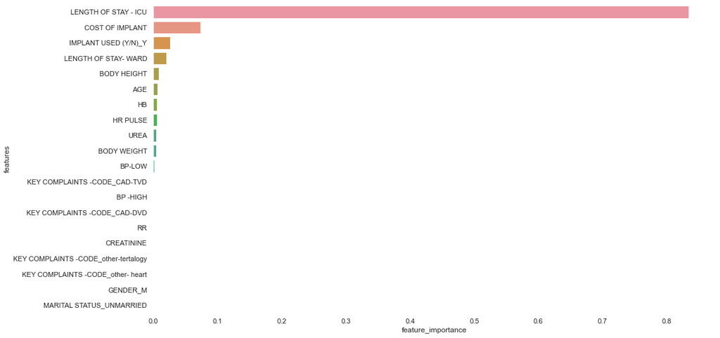

```python
plot_features(X_train.columns, ideal_model.feature_importances_)
```

## 7. Conclusion

Other important predictors:

In my research I found out that according to London Health Sciences Center*, **elevated creatinine and urea indicates that the kidneys are not working, also known as renal failure. And according to healthline.com**, one of the symptoms of renal failure is confusion. Which could possibly be a reason why those features came out statistically significant.

**Hypothesis:** a person with renal failure is received at the hospital in a confused state with elevated creatinine and urea levels, who most likely will need an implant which costs money and will most likely be admitted in the ICU for X amount of days, the model will be able to predict the cost the hospital will incur for the patient.

https://www.lhsc.on.ca/critical-care-trauma-centre/critical-care-trauma-centre-30

https://www.healthline.com/health/kidney-failure